# 603 Assignment 1 Multiple Linear Regression

## Problem 1

**a**

```r
options(scipen = 999)
tires=read.csv("tires.csv", header = TRUE)
head(tires)
```

```
##   type wear ave
## 1    A  0.3  80
## 2    A  0.3  80
## 3    A  0.3  80
## 4    A  0.3  80
## 5    A  0.3  80
## 6    A  0.3  80
```

```r
tail(tires)
```

```
##     type wear ave
## 135    B  0.9 113
## 136    B  0.9 111
## 137    B  0.9 113
## 138    B  0.9 111
## 139    B  0.9 113
## 140    B  0.9 111
```

```r
fullmodel = lm(wear~ave+factor(type), data=tires) # (Full) model with all variables
```

The statistical hypothesis to be tested is:

$$\begin{aligned}
H_0&:\beta_i=0\\
H_a&:\beta_i\neq0\mbox{ (i=1,2)}
\end{aligned}$$
I set up the $\alpha = 0.05$

```r
summary(fullmodel)
```

```
##
## Call:
## lm(formula = wear ~ ave + factor(type), data = tires)
##
## Residuals:
##       Min        1Q    Median        3Q       Max
## -0.092858 -0.033451 -0.000953  0.039404  0.116668
##
## Coefficients:
##                 Estimate Std. Error t value            Pr(>|t|)
## (Intercept)   -0.6445083  0.0525675  -12.26 <0.0000000000000002 ***
## ave            0.0113094  0.0005155   21.94 <0.0000000000000002 ***
## factor(type)B  0.1725006  0.0093544   18.44 <0.0000000000000002 ***
## ---
## Signif. codes:  0 '***' 0.001 '**' 0.01 '*' 0.05 '.' 0.1 ' ' 1
##
## Residual standard error: 0.05384 on 137 degrees of freedom
## Multiple R-squared:  0.8861, Adjusted R-squared:  0.8844
## F-statistic: 532.8 on 2 and 137 DF,  p-value: < 0.00000000000000022
```

It shows that the ave has $tcal=21.94$ with the $p-value <0.0000000000000002 < 0.05$, indicating that we Reject the null hypothesis that the average speed in km/hour has significantly influence on wear at $α=0.05$.

type has $tcal=18.44$ with the $p-value <0.0000000000000002 < 0.05$, indicating that we Reject the null hypothesis that the type has significantly influence on wear at $α=0.05$.

The estimated model is:
$$\begin{aligned}
\widehat{Wear_i}&=-0.6445083 + 0.0113094Ave +0.1725006Type_i\\
\end{aligned}$$
$$\widehat{Wear_i}= 0.0113094Ave +
\begin{cases}
-0.6445083+ 0.1725006 & \mbox{if } i^{th}\mbox{tire is a Type B} \\
-0.6445083 & \mbox{if } i^{th}\mbox{tire is a Type A}
\end{cases}$$
**b** The dummy variable is type of tires which has 2 types, type A and type B, $\beta_2 = 0.1725006$ as the average difference in tread wear between Type B and Type A.

**c**

Interpretation:

$\beta_0 = -0.6445083$ can be interpreted as the average difference in tread wear per 160 km in the percentage among Type A tires,

$\beta_2 = 0.1725006$ can be interpreted as the average difference in tread wear per 160 km in the percentage among Type B tires.

$\beta_1 = 0.0113094$ means that for a given type of tire, increase 1 km/h of average speed leads to an increase in tread wear by approximately 0.0113094 percentage.

**d**

```r
interacmodel<-lm(wear~(ave+factor(type))^2, data=tires)
```

For testing an interaction term in regression model, we use the Individual Coefficients Test (t-test) method.

$$\begin{aligned}
H_0&:\beta_i=0\\
H_a&:\beta_i\neq0\mbox{ (i=1,2,3)}\\\\\\
\end{aligned}$$
I set up the $\alpha = 0.05$

```r
summary(interacmodel)
```

```
##
## Call:
## lm(formula = wear ~ (ave + factor(type))^2, data = tires)
##
## Residuals:
##       Min        1Q    Median        3Q       Max
## -0.070158 -0.016493 -0.003643  0.024086  0.063703
##
## Coefficients:
##                     Estimate Std. Error t value            Pr(>|t|)
## (Intercept)       -0.3888744  0.0347705  -11.18 <0.0000000000000002 ***
## ave                0.0087833  0.0003415   25.72 <0.0000000000000002 ***
## factor(type)B     -1.0800050  0.0779442  -13.86 <0.0000000000000002 ***
## ave:factor(type)B  0.0119840  0.0007439   16.11 <0.0000000000000002 ***
## ---
## Signif. codes:  0 '***' 0.001 '**' 0.01 '*' 0.05 '.' 0.1 ' ' 1
##
## Residual standard error: 0.03169 on 136 degrees of freedom
## Multiple R-squared:  0.9608, Adjusted R-squared:   0.96
## F-statistic:  1112 on 3 and 136 DF,  p-value: < 0.00000000000000022
```

From the out put, It shows that the interaction term ave*type has $t_{cal}=16.11$ with the $p-value <0.0000000000000002< 0.05$, indicating that we should clearly Reject the null hypothesis for them which means that we should add this interaction term to the model at $α=0.05$.

The model I suggest using for predicting y is:
$$\begin{aligned}
\widehat{Wear_i}&=-0.3888744 + 0.0087833Ave -1.0800050Type_i +
0.0119840Ave*Type_i\\
\end{aligned}$$

**e** The adjusted-R2 value from the model in part (d) is 0.96 Interpretation: For the model, $R^2_{adj} = 0.96$ that means the model explains 96% of the variation of the response variable tread wear.

**f**

```r
newdata = data.frame(ave= 100, type = 'A' )
predict(interacmodel,newdata,interval="predict")
```

```
##       fit       lwr       upr
## 1 0.48946 0.4263475 0.5525725
```

Interpretation:

When a car with type A with the average speed of 100 km/hour, the fit prediction for the average tread wear per 160 km in the percentage of tread thickness is 0.48946 or 48.946%

## Problem 2

**a**

```r
mh=read.csv("MentalHealth.csv", header = TRUE)
head(mh)
```

```
##   EFFECT AGE METHOD
## 1     56  21      A
## 2     41  23      B
## 3     40  30      B
## 4     28  19      C
## 5     55  28      A
## 6     25  23      C
```

```r
tail(mh)
```

```
##    EFFECT AGE METHOD
## 31     60  67      B
## 32     62  63      A
## 33     71  59      C
## 34     62  51      C
## 35     70  67      A
## 36     71  63      C
```

The dependent variable is EFFECT.

**b** The independent variables are AGE and METHOD.

**c**

```r
mixmodel<- lm(EFFECT~AGE+factor(METHOD),data=mh)
summary(mixmodel)
```

```
##
## Call:
## lm(formula = EFFECT ~ AGE + factor(METHOD), data = mh)
##
## Residuals:
##      Min       1Q   Median       3Q      Max
## -12.5732  -3.3922   0.9829   3.9613   9.5062
##
## Coefficients:
##                  Estimate Std. Error t value        Pr(>|t|)
## (Intercept)      32.54335    3.58105   9.088 0.0000000002231 ***
## AGE               0.66446    0.06978   9.522 0.0000000000742 ***
## factor(METHOD)B  -9.80758    2.46471  -3.979        0.000371 ***
## factor(METHOD)C -10.25276    2.46542  -4.159        0.000224 ***
## ---
## Signif. codes:  0 '***' 0.001 '**' 0.01 '*' 0.05 '.' 0.1 ' ' 1
##
## Residual standard error: 6.035 on 32 degrees of freedom
## Multiple R-squared:  0.784,  Adjusted R-squared:  0.7637
## F-statistic: 38.71 on 3 and 32 DF,  p-value: 0.00000000009287
```

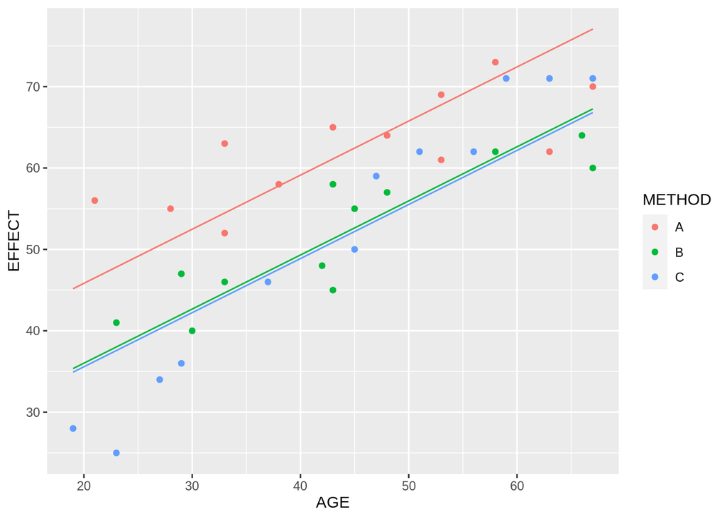

```r
#For student y=593.8135+5.9843Income
#For nonstudent  y=211.1430+5.9843 Income
ma=function(x){coef(mixmodel)[2]*x+coef(mixmodel)[1]}
mb=function(x){coef(mixmodel)[2]*x+coef(mixmodel)[1]+coef(mixmodel)[3]}
mc = function(x){coef(mixmodel)[2]*x+coef(mixmodel)[1]+ coef(mixmodel)[4]}
ggplot(data=mh,mapping= aes(y=EFFECT,x=AGE,colour=METHOD))+geom_point()+
  stat_function(fun=ma,geom="line",color=scales::hue_pal()(3)[1])+
  stat_function(fun=mb,geom="line",color=scales::hue_pal()(3)[2])+
  stat_function(fun=mc,geom="line",color=scales::hue_pal()(3)[3])
```

Notice that this amounts to fitting 3 parallel lines to the data, for METHOD A , METHOD B and METHOD C. This 3 lines have different intercepts, but the same slope, $β_1$. The fact that the lines are parallel means that the average effect on EFFECT of a 1 unit increase in AGE does not depend on the METHOD used. This represents a potentially serious limitation of the model.

**d**

```r
interacmodel2<-lm(EFFECT~(AGE+factor(METHOD))^2, data=mh)
```

For testing an interaction term in regression model, we use the Individual Coefficients Test (t-test) method.

$$\begin{aligned}
H_0&:\beta_i=0\\
H_a&:\beta_i\neq0\mbox{ (i=1,2,3)}\\\\\\
\end{aligned}$$
I set up the $\alpha = 0.05$

```r
summary(interacmodel2)
```

```
##
## Call:
## lm(formula = EFFECT ~ (AGE + factor(METHOD))^2, data = mh)
##
## Residuals:
##     Min      1Q  Median      3Q     Max
## -6.4366 -2.7637  0.1887  2.9075  6.5634
##
## Coefficients:
##                      Estimate Std. Error t value          Pr(>|t|)
## (Intercept)          47.51559    3.82523  12.422 0.000000000000234 ***
## AGE                   0.33051    0.08149   4.056          0.000328 ***
## factor(METHOD)B     -18.59739    5.41573  -3.434          0.001759 **
## factor(METHOD)C     -41.30421    5.08453  -8.124 0.000000004555079 ***
## AGE:factor(METHOD)B   0.19318    0.11660   1.657          0.108001
## AGE:factor(METHOD)C   0.70288    0.10896   6.451 0.000000398247265 ***
## ---
## Signif. codes:  0 '***' 0.001 '**' 0.01 '*' 0.05 '.' 0.1 ' ' 1
##
## Residual standard error: 3.925 on 30 degrees of freedom
## Multiple R-squared:  0.9143, Adjusted R-squared:  0.9001
## F-statistic: 64.04 on 5 and 30 DF,  p-value: 0.000000000000004264
```

From the out put, It shows that the interaction term AGE*METHOD has $t_{cal}=6.451$ with the $p-value <0.000000398247265 < 0.05$, indicating that we should clearly Reject the null hypothesis for them which means that we should add this interaction term to the model at $α=0.05$.

**g**

```r
coef(interacmodel2)
```

```
##         (Intercept)                 AGE     factor(METHOD)B     factor(METHOD)C
##          47.5155913           0.3305073         -18.5973852         -41.3042101
## AGE:factor(METHOD)B AGE:factor(METHOD)C
##           0.1931769           0.7028836
```

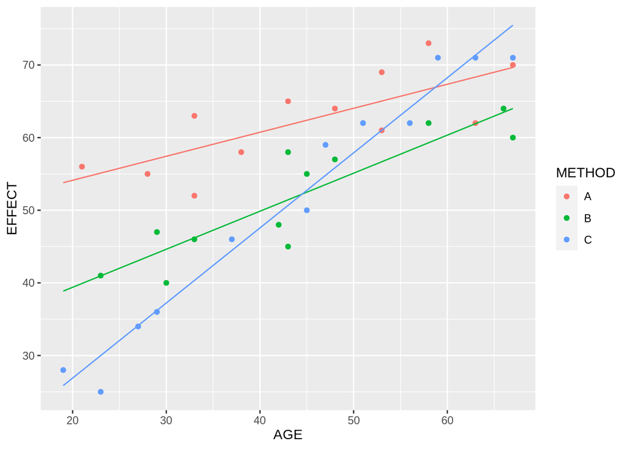

```r
#For student y=593.8135+5.9843Income
#For nonstudent  y=211.1430+5.9843 Income
ta=function(x){0.33051*x+47.51559}
tb=function(x){0.52369*x+28.9182}
tc=function(x){1.0339*x+6.21138}
ggplot(data=mh,mapping= aes(y=EFFECT,x=AGE,colour=METHOD))+geom_point()+
  stat_function(fun=ta,geom="line",color=scales::hue_pal()(3)[1])+
  stat_function(fun=tb,geom="line",color=scales::hue_pal()(3)[2])+
  stat_function(fun=tc,geom="line",color=scales::hue_pal()(3)[3])
```

## Problem 3

**a**

```r
q3=read.table(file = "FLAG2.txt", header = TRUE)
head(q3)
```

```
##    LOWBID  DOTEST LBERATIO STATUS DISTRICT NUMIDS DAYSEST RDLNGTH  PCTASPH
## 1  362916  385963  0.94029      0        1      3     100   7.200 0.626369
## 2  152056  175396  0.86693      1        1      3      75   0.000 0.153284
## 3  239665  194650  1.23126      1        1      3      65   0.206 0.082670
## 4 1559368 1925307  0.80993      0        1     10     250   3.600 0.189911
## 5  144062  252925  0.56958      0        1      8      90  23.700 0.316169
## 6 1187104 1573451  0.75446      0        1      5     230   2.600 0.281976
##    PCTBASE PCTEXCAV PCTMOBIL PCTSTRUC PCTTRAF SUBCONT
## 1 0.000000 0.091475 0.019977 0.116770 0.09170       0
## 2 0.012364 0.142221 0.047351 0.018020 0.14764       0
## 3 0.000000 0.105314 0.049235 0.222602 0.06029       0
## 4 0.298819 0.238240 0.011543 0.166206 0.04054       0
## 5 0.245298 0.159904 0.003471 0.082562 0.00882       0
## 6 0.214393 0.241728 0.008424 0.147573 0.02250       0
```

```r
tail(q3)
```

```
##      LOWBID  DOTEST LBERATIO STATUS DISTRICT NUMIDS DAYSEST RDLNGTH  PCTASPH
## 274 1217569 1341081  0.90790      0        2     11     350  2.0000 0.142159
## 275 2229343 2434603  0.91569      0        2      6     450  0.2102 0.144600
## 276  168532  163669  1.02971      0        2      8      30  0.9763 0.000000
## 277   95857   95630  1.00238      0        2      8      30  0.9583 0.000000
## 278  106918  107895  0.99094      0        2      7      30  0.9348 0.000000
## 279  666773  641521  1.03936      0        2      5     240  0.0000 0.492985
##      PCTBASE PCTEXCAV PCTMOBIL PCTSTRUC PCTTRAF SUBCONT
## 274 0.131608 0.175051 0.012320 0.269048 0.03389       0
## 275 0.121980 0.015700 0.282224 0.026821 0.00000       *
## 276 0.000000 0.011867 0.000000 0.011867 0.00000       *
## 277 0.000000 0.026080 0.000000 0.015648 0.00000       *
## 278 0.000000 0.028059 0.003741 0.028994 0.00000       *
## 279 0.054745 0.232318 0.007499 0.111355 0.04499       0
```

```r
library(olsrr)#need to install the package olsrr
fullmodel<-lm(LOWBID~DOTEST+factor(STATUS)+factor(DISTRICT)+NUMIDS+DAYSEST+RDLNGTH+ PCTASPH + PCTBASE + PCTEXCAV + PCTMOBIL + PCTSTRUC + PCTTRAF, data = q3)
summary(fullmodel)
```

```
##
## Call:
## lm(formula = LOWBID ~ DOTEST + factor(STATUS) + factor(DISTRICT) +
##     NUMIDS + DAYSEST + RDLNGTH + PCTASPH + PCTBASE + PCTEXCAV +
##     PCTMOBIL + PCTSTRUC + PCTTRAF, data = q3)
##
## Residuals:
##      Min       1Q   Median       3Q      Max
## -2061552   -76832     3703    68246  1592629
##
## Coefficients:
##                        Estimate    Std. Error t value            Pr(>|t|)
## (Intercept)         76232.50277   69164.11042   1.102              0.2714
## DOTEST                  0.93617       0.01687  55.494 <0.0000000000000002 ***
## factor(STATUS)1    108861.47470   42631.97933   2.554              0.0112 *
## factor(DISTRICT)2   77727.22389   63877.16964   1.217              0.2248
## factor(DISTRICT)3   29603.14038  204212.89374   0.145              0.8849
## factor(DISTRICT)4 -272885.77878  137654.30165  -1.982              0.0485 *
## factor(DISTRICT)5  -24195.84506   37992.29325  -0.637              0.5248
## NUMIDS             -22429.92410    8797.41520  -2.550              0.0114 *
## DAYSEST                80.30215     184.83628   0.434              0.6643
## RDLNGTH              5668.51317    4926.04007   1.151              0.2509
## PCTASPH           -102248.76428   79846.70689  -1.281              0.2015
## PCTBASE            251624.97627  184029.12097   1.367              0.1727
## PCTEXCAV          -282430.97222  160989.86978  -1.754              0.0805 .
## PCTMOBIL           332192.34682  276548.05188   1.201              0.2308
## PCTSTRUC           145905.63892  162143.92354   0.900              0.3690
## PCTTRAF           -100170.75828  141617.22028  -0.707              0.4800
## ---
## Signif. codes:  0 '***' 0.001 '**' 0.01 '*' 0.05 '.' 0.1 ' ' 1
##
## Residual standard error: 278000 on 263 degrees of freedom
## Multiple R-squared:  0.978,  Adjusted R-squared:  0.9768
## F-statistic: 780.2 on 15 and 263 DF,  p-value: < 0.00000000000000022
```

```r
stepmod=ols_step_both_p(fullmodel,pent = 0.05, prem = 0.1, details=TRUE)
```

```
## Stepwise Selection Method
## ---------------------------
##
## Candidate Terms:
##
## 1. DOTEST
## 2. factor(STATUS)
## 3. factor(DISTRICT)
## 4. NUMIDS
## 5. DAYSEST
## 6. RDLNGTH
## 7. PCTASPH
## 8. PCTBASE
## 9. PCTEXCAV
## 10. PCTMOBIL
## 11. PCTSTRUC
## 12. PCTTRAF
##
## We are selecting variables based on p value...
##
##
## Stepwise Selection: Step 1
##
## - DOTEST added
##
##                              Model Summary
## -----------------------------------------------------------------------
## R                       0.987       RMSE                    289264.494
## R-Squared               0.975       Coef. Var                   25.283
## Adj. R-Squared          0.975       MSE                83673947406.590
## Pred R-Squared          0.973       MAE                     136785.248
## -----------------------------------------------------------------------
##  RMSE: Root Mean Square Error
##  MSE: Mean Square Error
##  MAE: Mean Absolute Error
##
##                                            ANOVA
## -------------------------------------------------------------------------------------------
##                            Sum of
##                           Squares         DF            Mean Square        F          Sig.
```

[output cut: 175 more lines]

```
## ------------------------------------------------------------------------------------------
## Regression    902691683522890.250          3    300897227840963.438     3792.15    0.0000
## Residual       21820534874830.578        275        79347399544.838
## Total         924512218397720.875        278
## ------------------------------------------------------------------------------------------
##
##                                            Parameter Estimates
## ---------------------------------------------------------------------------------------------------------
##           model          Beta    Std. Error    Std. Beta       t        Sig          lower         upper
## ---------------------------------------------------------------------------------------------------------
##     (Intercept)     57105.973     45823.264                   1.246    0.214    -33102.981    147314.927
##          DOTEST         0.937         0.009        1.000    101.011    0.000         0.919         0.956
## factor(STATUS)1     95252.389     41959.825        0.024      2.270    0.024     12649.108    177855.670
##          NUMIDS    -15353.820      7530.216       -0.023     -2.039    0.042    -30178.014      -529.626
## ---------------------------------------------------------------------------------------------------------
```

```r
summary(stepmod$model)
```

```
##
## Call:
## lm(formula = paste(response, "~", paste(preds, collapse = " + ")),
##     data = l)
##
## Residuals:
##      Min       1Q   Median       3Q      Max
## -2127947   -62934    -7025    59043  1665603
##
## Coefficients:
##                     Estimate   Std. Error t value            Pr(>|t|)
## (Intercept)      57105.97270  45823.26366   1.246              0.2137
## DOTEST               0.93743      0.00928 101.011 <0.0000000000000002 ***
## factor(STATUS)1  95252.38907  41959.82501   2.270              0.0240 *
## NUMIDS          -15353.81995   7530.21626  -2.039              0.0424 *
## ---
## Signif. codes:  0 '***' 0.001 '**' 0.01 '*' 0.05 '.' 0.1 ' ' 1
##
## Residual standard error: 281700 on 275 degrees of freedom
## Multiple R-squared:  0.9764, Adjusted R-squared:  0.9761
## F-statistic:  3792 on 3 and 275 DF,  p-value: < 0.00000000000000022
```

The output shows that the independent variables most suitable for modeling Y is DOTEST, STATUS and NUMIDS. The final model is:

$$\begin{aligned}
\hat{Y_i}&=57105.97270 + 0.93743DOTEST_i + 95252.38907 STATUS_{i1} -
15353.81995 NUMIDS_i\\
\widehat{LOWBID_i}&=
\begin{cases}
57105.97270+ 0.93743DOTEST_i - 15353.81995 NUMIDS_i & \mbox{if }
i^{th}\mbox{ contract is competitive)} \\
152358.3618 + 0.93743DOTEST_i - 15353.81995 NUMIDS_i & \mbox{if }
i^{th}\mbox{ contract is fixed}
\end{cases}
\end{aligned}$$

**b**

```r
formodel=ols_step_forward_p(fullmodel,penter = 0.05, details=TRUE)
```

```
## Forward Selection Method
## ---------------------------
##
## Candidate Terms:
##
## 1. DOTEST
## 2. factor(STATUS)
## 3. factor(DISTRICT)
## 4. NUMIDS
## 5. DAYSEST
## 6. RDLNGTH
## 7. PCTASPH
## 8. PCTBASE
## 9. PCTEXCAV
## 10. PCTMOBIL
## 11. PCTSTRUC
## 12. PCTTRAF
##
## We are selecting variables based on p value...
##
##
## Forward Selection: Step 1
##
## - DOTEST
##
##                              Model Summary
## -----------------------------------------------------------------------
## R                       0.987       RMSE                    289264.494
## R-Squared               0.975       Coef. Var                   25.283
## Adj. R-Squared          0.975       MSE                83673947406.590
## Pred R-Squared          0.973       MAE                     136785.248
## -----------------------------------------------------------------------
##  RMSE: Root Mean Square Error
##  MSE: Mean Square Error
##  MAE: Mean Absolute Error
##
##                                            ANOVA
## -------------------------------------------------------------------------------------------
##                            Sum of
##                           Squares         DF            Mean Square        F          Sig.
```

[output cut: 116 more lines]

```
## ------------------------------------------------------------------------------------------
## Regression    902691683522890.250          3    300897227840963.438     3792.15    0.0000
## Residual       21820534874830.578        275        79347399544.838
## Total         924512218397720.875        278
## ------------------------------------------------------------------------------------------
##
##                                            Parameter Estimates
## ---------------------------------------------------------------------------------------------------------
##           model          Beta    Std. Error    Std. Beta       t        Sig          lower         upper
## ---------------------------------------------------------------------------------------------------------
##     (Intercept)     57105.973     45823.264                   1.246    0.214    -33102.981    147314.927
##          DOTEST         0.937         0.009        1.000    101.011    0.000         0.919         0.956
## factor(STATUS)1     95252.389     41959.825        0.024      2.270    0.024     12649.108    177855.670
##          NUMIDS    -15353.820      7530.216       -0.023     -2.039    0.042    -30178.014      -529.626
## ---------------------------------------------------------------------------------------------------------
```

```r
summary(formodel$model)
```

```
##
## Call:
## lm(formula = paste(response, "~", paste(preds, collapse = " + ")),
##     data = l)
##
## Residuals:
##      Min       1Q   Median       3Q      Max
## -2127947   -62934    -7025    59043  1665603
##
## Coefficients:
##                     Estimate   Std. Error t value            Pr(>|t|)
## (Intercept)      57105.97270  45823.26366   1.246              0.2137
## DOTEST               0.93743      0.00928 101.011 <0.0000000000000002 ***
## factor(STATUS)1  95252.38907  41959.82501   2.270              0.0240 *
## NUMIDS          -15353.81995   7530.21626  -2.039              0.0424 *
## ---
## Signif. codes:  0 '***' 0.001 '**' 0.01 '*' 0.05 '.' 0.1 ' ' 1
##
## Residual standard error: 281700 on 275 degrees of freedom
## Multiple R-squared:  0.9764, Adjusted R-squared:  0.9761
## F-statistic:  3792 on 3 and 275 DF,  p-value: < 0.00000000000000022
```

The output shows that the independent variables most suitable for modeling Y is DOTEST, STATUS and NUMIDS. The final model is:

$$\begin{aligned}
\hat{Y_i}&=57105.97270 + 0.93743DOTEST_i + 95252.38907 STATUS_{i1} -
15353.81995 NUMIDS_i\\
\widehat{LOWBID_i}&=
\begin{cases}
57105.97270+ 0.93743DOTEST_i - 15353.81995 NUMIDS_i & \mbox{if }
i^{th}\mbox{ contract is competitive)} \\
152358.3618 + 0.93743DOTEST_i - 15353.81995 NUMIDS_i & \mbox{if }
i^{th}\mbox{ contract is fixed}
\end{cases}
\end{aligned}$$

**c**

```r
backmodel=ols_step_backward_p(fullmodel, prem = 0.05, details=TRUE)
```

```
## Backward Elimination Method
## ---------------------------
##
## Candidate Terms:
##
## 1 . DOTEST
## 2 . factor(STATUS)
## 3 . factor(DISTRICT)
## 4 . NUMIDS
## 5 . DAYSEST
## 6 . RDLNGTH
## 7 . PCTASPH
## 8 . PCTBASE
## 9 . PCTEXCAV
## 10 . PCTMOBIL
## 11 . PCTSTRUC
## 12 . PCTTRAF
##
## We are eliminating variables based on p value...
##
## - DAYSEST
##
## Backward Elimination: Step 1
##
##  Variable DAYSEST Removed
##
##                              Model Summary
## -----------------------------------------------------------------------
## R                       0.989       RMSE                    277539.359
## R-Squared               0.978       Coef. Var                   24.258
## Adj. R-Squared          0.977       MSE                77028095662.593
## Pred R-Squared          0.974       MAE                     139078.135
## -----------------------------------------------------------------------
##  RMSE: Root Mean Square Error
##  MSE: Mean Square Error
##  MAE: Mean Absolute Error
##
##                                          ANOVA
## ----------------------------------------------------------------------------------------
##                            Sum of
```

[output cut: 411 more lines]

```
## ------------------------------------------------------------------------------------------
## Regression    902691683522890.250          3    300897227840963.438     3792.15    0.0000
## Residual       21820534874830.578        275        79347399544.838
## Total         924512218397720.875        278
## ------------------------------------------------------------------------------------------
##
##                                            Parameter Estimates
## ---------------------------------------------------------------------------------------------------------
##           model          Beta    Std. Error    Std. Beta       t        Sig          lower         upper
## ---------------------------------------------------------------------------------------------------------
##     (Intercept)     57105.973     45823.264                   1.246    0.214    -33102.981    147314.927
##          DOTEST         0.937         0.009        1.000    101.011    0.000         0.919         0.956
## factor(STATUS)1     95252.389     41959.825        0.024      2.270    0.024     12649.108    177855.670
##          NUMIDS    -15353.820      7530.216       -0.023     -2.039    0.042    -30178.014      -529.626
## ---------------------------------------------------------------------------------------------------------
```

```r
summary(backmodel$model)
```

```
##
## Call:
## lm(formula = paste(response, "~", paste(preds, collapse = " + ")),
##     data = l)
##
## Residuals:
##      Min       1Q   Median       3Q      Max
## -2127947   -62934    -7025    59043  1665603
##
## Coefficients:
##                     Estimate   Std. Error t value            Pr(>|t|)
## (Intercept)      57105.97270  45823.26366   1.246              0.2137
## DOTEST               0.93743      0.00928 101.011 <0.0000000000000002 ***
## factor(STATUS)1  95252.38907  41959.82501   2.270              0.0240 *
## NUMIDS          -15353.81995   7530.21626  -2.039              0.0424 *
## ---
## Signif. codes:  0 '***' 0.001 '**' 0.01 '*' 0.05 '.' 0.1 ' ' 1
##
## Residual standard error: 281700 on 275 degrees of freedom
## Multiple R-squared:  0.9764, Adjusted R-squared:  0.9761
## F-statistic:  3792 on 3 and 275 DF,  p-value: < 0.00000000000000022
```

The output shows that the independent variables most suitable for modeling Y is DOTEST, STATUS and NUMIDS. The final model is:

$$\begin{aligned}
\hat{Y_i}&=57105.97270 + 0.93743DOTEST_i + 95252.38907 STATUS_{i1} -
15353.81995 NUMIDS_i\\
\widehat{LOWBID_i}&=
\begin{cases}
57105.97270+ 0.93743DOTEST_i - 15353.81995 NUMIDS_i & \mbox{if }
i^{th}\mbox{ contract is competitive)} \\
152358.3618 + 0.93743DOTEST_i - 15353.81995 NUMIDS_i & \mbox{if }
i^{th}\mbox{ contract is fixed}
\end{cases}
\end{aligned}$$

**d**

Individual Coefficients Test (t-test) :
$$\begin{aligned}
H_0&:\beta_i=0\\
H_a&:\beta_i\neq0\mbox{ (i=1,2,...,12)}\\
\end{aligned}$$
I set up the $\alpha = 0.05$

```r
summary(fullmodel)
```

```
##
## Call:
## lm(formula = LOWBID ~ DOTEST + factor(STATUS) + factor(DISTRICT) +
##     NUMIDS + DAYSEST + RDLNGTH + PCTASPH + PCTBASE + PCTEXCAV +
##     PCTMOBIL + PCTSTRUC + PCTTRAF, data = q3)
##
## Residuals:
##      Min       1Q   Median       3Q      Max
## -2061552   -76832     3703    68246  1592629
##
## Coefficients:
##                        Estimate    Std. Error t value            Pr(>|t|)
## (Intercept)         76232.50277   69164.11042   1.102              0.2714
## DOTEST                  0.93617       0.01687  55.494 <0.0000000000000002 ***
## factor(STATUS)1    108861.47470   42631.97933   2.554              0.0112 *
## factor(DISTRICT)2   77727.22389   63877.16964   1.217              0.2248
## factor(DISTRICT)3   29603.14038  204212.89374   0.145              0.8849
## factor(DISTRICT)4 -272885.77878  137654.30165  -1.982              0.0485 *
## factor(DISTRICT)5  -24195.84506   37992.29325  -0.637              0.5248
## NUMIDS             -22429.92410    8797.41520  -2.550              0.0114 *
## DAYSEST                80.30215     184.83628   0.434              0.6643
## RDLNGTH              5668.51317    4926.04007   1.151              0.2509
## PCTASPH           -102248.76428   79846.70689  -1.281              0.2015
## PCTBASE            251624.97627  184029.12097   1.367              0.1727
## PCTEXCAV          -282430.97222  160989.86978  -1.754              0.0805 .
## PCTMOBIL           332192.34682  276548.05188   1.201              0.2308
## PCTSTRUC           145905.63892  162143.92354   0.900              0.3690
## PCTTRAF           -100170.75828  141617.22028  -0.707              0.4800
## ---
## Signif. codes:  0 '***' 0.001 '**' 0.01 '*' 0.05 '.' 0.1 ' ' 1
##
## Residual standard error: 278000 on 263 degrees of freedom
## Multiple R-squared:  0.978,  Adjusted R-squared:  0.9768
## F-statistic: 780.2 on 15 and 263 DF,  p-value: < 0.00000000000000022
```

From the out put, It shows that: DAYSEST has $p-value= 0.6643> 0.05$, RDLNGTH has $p-value= 0.2509> 0.05$, PCTASPH has $p-value= 0.2015> 0.05$, PCTBASE has $p-value= 0.1727> 0.05$, PCTEXCAV has $p-value= 0.0805> 0.05$, PCTMOBIL has $p-value= 0.2308> 0.05$, PCTSTRUC has $p-value= 0.3690> 0.05$, PCTTRAF has $p-value= 0.4800> 0.05$, indicating that we should clearly not to reject the null hypothesis for them which means that we should not add those variables to the model at $α=0.05$.

From the out put, It shows that the variable DOTEST has $t_{cal}=55.494$ with the $p-value< 0.0000000000000002 < 0.05$ , STATUS has $t_{cal}=2.554$ with the $p-value = 0.0112 < 0.05$ , DISTRICT has $p-value = 0.0485 < 0.05$ and NUMIDS has $t_{cal}=-2.550$ with the $p-value= 0.0114 < 0.05$, indicating that we should clearly reject the null hypothesis for those which means that we should add those variables to the model at $α=0.05$.

```r
reducm <-lm(LOWBID~DOTEST+factor(STATUS)+factor(DISTRICT)+NUMIDS, data = q3)
summary(reducm)
```

```
##
## Call:
## lm(formula = LOWBID ~ DOTEST + factor(STATUS) + factor(DISTRICT) +
##     NUMIDS, data = q3)
##
## Residuals:
##      Min       1Q   Median       3Q      Max
## -2160166   -66952    -6042    55358  1625579
##
## Coefficients:
##                        Estimate    Std. Error t value            Pr(>|t|)
## (Intercept)         60498.36032   51970.36595   1.164              0.2454
## DOTEST                  0.94474       0.01002  94.258 <0.0000000000000002 ***
## factor(STATUS)1     99908.88953   41892.08644   2.385              0.0178 *
## factor(DISTRICT)2   70997.36495   63157.21720   1.124              0.2619
## factor(DISTRICT)3   11563.79117  203815.38943   0.057              0.9548
## factor(DISTRICT)4 -316505.61879  133557.06113  -2.370              0.0185 *
## factor(DISTRICT)5  -14151.26611   37332.99493  -0.379              0.7049
## NUMIDS             -17361.29713    8255.21048  -2.103              0.0364 *
## ---
## Signif. codes:  0 '***' 0.001 '**' 0.01 '*' 0.05 '.' 0.1 ' ' 1
##
## Residual standard error: 279700 on 271 degrees of freedom
## Multiple R-squared:  0.9771, Adjusted R-squared:  0.9765
## F-statistic:  1650 on 7 and 271 DF,  p-value: < 0.00000000000000022
```

**e** Model for 3d:

$$
$$\begin{aligned}
\hat{Y_i}&=60498.36032 + 0.94474 DOTEST_i + 99908.88953 STATUS_{i}
-17361.29713 NUMIDS_i + 70997.36495 DISTRICT_{i2} + 11563.79117
DISTRICT_{i3} -316505.61879 DISTRICT_{i4} -14151.26611 DISTRICT_{i5}\\
\end{aligned}$$

Model for 3a,3b,3c:
$$\begin{aligned}
\hat{Y_i}&=57105.97270 + 0.93743DOTEST_i + 95252.38907 STATUS_{i1} -
15353.81995 NUMIDS_i\\
\widehat{LOWBID_i}&=
\begin{cases}
57105.97270+ 0.93743DOTEST_i - 15353.81995 NUMIDS_i & \mbox{if }
i^{th}\mbox{ contract is competitive)} \\
152358.3618 + 0.93743DOTEST_i - 15353.81995 NUMIDS_i & \mbox{if }
i^{th}\mbox{ contract is fixed}
\end{cases}
\end{aligned}$$

**f**

```r
reducm <-lm(LOWBID~DOTEST+factor(STATUS)+factor(DISTRICT)+NUMIDS, data = q3)
summary(reducm)
```

```
##
## Call:
## lm(formula = LOWBID ~ DOTEST + factor(STATUS) + factor(DISTRICT) +
##     NUMIDS, data = q3)
##
## Residuals:
##      Min       1Q   Median       3Q      Max
## -2160166   -66952    -6042    55358  1625579
##
## Coefficients:
##                        Estimate    Std. Error t value            Pr(>|t|)
## (Intercept)         60498.36032   51970.36595   1.164              0.2454
## DOTEST                  0.94474       0.01002  94.258 <0.0000000000000002 ***
## factor(STATUS)1     99908.88953   41892.08644   2.385              0.0178 *
## factor(DISTRICT)2   70997.36495   63157.21720   1.124              0.2619
## factor(DISTRICT)3   11563.79117  203815.38943   0.057              0.9548
## factor(DISTRICT)4 -316505.61879  133557.06113  -2.370              0.0185 *
## factor(DISTRICT)5  -14151.26611   37332.99493  -0.379              0.7049
## NUMIDS             -17361.29713    8255.21048  -2.103              0.0364 *
## ---
## Signif. codes:  0 '***' 0.001 '**' 0.01 '*' 0.05 '.' 0.1 ' ' 1
##
## Residual standard error: 279700 on 271 degrees of freedom
## Multiple R-squared:  0.9771, Adjusted R-squared:  0.9765
## F-statistic:  1650 on 7 and 271 DF,  p-value: < 0.00000000000000022
```

The absolute difference in average contact bid price (by the lowest bidder) between District 1 and 4 is 316505.61879,when other predictors are held as a constant.

**g**

```r
abs(-14151.26611 - 70997.36495 )
```

```
## [1] 85148.63
```

The difference in average contact bid price (by the lowest bidder) between District 2 and 5 is 85148.63,when other predictors are held as a constant.

**h** Individual Coefficients Test (t-test) :
$$\begin{aligned}
H_0&:\beta_i=0\\
H_a&:\beta_i\neq0\mbox{ (i=1,2,...,p)}\\
\end{aligned}$$

```r
interacmodelq3<-lm(LOWBID~(DOTEST+factor(STATUS)+factor(DISTRICT)+NUMIDS)^2, data=q3)
summary(interacmodelq3)
```

```
##
## Call:
## lm(formula = LOWBID ~ (DOTEST + factor(STATUS) + factor(DISTRICT) +
##     NUMIDS)^2, data = q3)
##
## Residuals:
##      Min       1Q   Median       3Q      Max
## -1486446   -52732     9513    46452  1477972
##
## Coefficients: (4 not defined because of singularities)
##                                          Estimate      Std. Error t value
## (Intercept)                         -33531.299250    74804.517804  -0.448
## DOTEST                                   1.097041        0.029686  36.955
## factor(STATUS)1                     -11991.440846   110184.610752  -0.109
## factor(DISTRICT)2                   -12149.855489   165322.110666  -0.073
## factor(DISTRICT)3                    90368.664800   380154.218548   0.238
## factor(DISTRICT)4                 -1531677.676150   656803.770031  -2.332
## factor(DISTRICT)5                   -44376.120006    96659.340492  -0.459
## NUMIDS                               -4697.039625    12731.458347  -0.369
## DOTEST:factor(STATUS)1                   0.094507        0.036727   2.573
## DOTEST:factor(DISTRICT)2                 0.039881        0.055769   0.715
## DOTEST:factor(DISTRICT)3                -0.165501        0.516802  -0.320
## DOTEST:factor(DISTRICT)4                -0.025325        0.062682  -0.404
## DOTEST:factor(DISTRICT)5                -0.133047        0.028701  -4.636
## DOTEST:NUMIDS                           -0.019338        0.003603  -5.367
## factor(STATUS)1:factor(DISTRICT)2              NA              NA      NA
## factor(STATUS)1:factor(DISTRICT)3              NA              NA      NA
## factor(STATUS)1:factor(DISTRICT)4              NA              NA      NA
## factor(STATUS)1:factor(DISTRICT)5    75485.912704    78908.043368   0.957
## factor(STATUS)1:NUMIDS               10433.338072    31876.431329   0.327
## factor(DISTRICT)2:NUMIDS              6114.368023    21657.872238   0.282
## factor(DISTRICT)3:NUMIDS                       NA              NA      NA
## factor(DISTRICT)4:NUMIDS            151948.203812    46611.036898   3.260
## factor(DISTRICT)5:NUMIDS             25250.822582    17983.706626   1.404
##                                               Pr(>|t|)
## (Intercept)                                    0.65434
## DOTEST                            < 0.0000000000000002 ***
## factor(STATUS)1                                0.91342
## factor(DISTRICT)2                              0.94147
## factor(DISTRICT)3                              0.81229
```

[output cut: 9 more lines]

```
## factor(STATUS)1:factor(DISTRICT)2                   NA
## factor(STATUS)1:factor(DISTRICT)3                   NA
## factor(STATUS)1:factor(DISTRICT)4                   NA
## factor(STATUS)1:factor(DISTRICT)5              0.33964
## factor(STATUS)1:NUMIDS                         0.74370
## factor(DISTRICT)2:NUMIDS                       0.77793
## factor(DISTRICT)3:NUMIDS                            NA
## factor(DISTRICT)4:NUMIDS                       0.00126 **
## factor(DISTRICT)5:NUMIDS                       0.16148
## ---
## Signif. codes:  0 '***' 0.001 '**' 0.01 '*' 0.05 '.' 0.1 ' ' 1
##
## Residual standard error: 251800 on 260 degrees of freedom
## Multiple R-squared:  0.9822, Adjusted R-squared:  0.9809
## F-statistic: 795.6 on 18 and 260 DF,  p-value: < 0.00000000000000022
```

From the out put, It shows that the interaction term DOTEST:STATUS has the $p-value= 0.01063 < 0.05$ and the interaction term DOTEST:DISTRICT has the $p-value= 0.000005636 < 0.05$, DOTEST:NUMIDS has the $p-value= 0.000000177< 0.05$, DISTRICT:NUMIDS has $p-value= 0.00126< 0.05$ indicating that we should clearly reject the null hypothesis for those which means that we should add those interaction terms to the model at $α=0.05$.

Individual Coefficients Test (t-test) :
$$\begin{aligned}
H_0&:\beta_i=0\\
H_a&:\beta_i\neq0\mbox{ (i=1,2,...,p)}\\
\end{aligned}$$

```r
reducinm <-lm(LOWBID~DOTEST+factor(STATUS)+factor(DISTRICT)+NUMIDS +DOTEST:factor(STATUS) + DOTEST:factor(DISTRICT) +  DOTEST:NUMIDS + NUMIDS:factor(DISTRICT) , data = q3)
summary(reducinm)
```

```
##
## Call:
## lm(formula = LOWBID ~ DOTEST + factor(STATUS) + factor(DISTRICT) +
##     NUMIDS + DOTEST:factor(STATUS) + DOTEST:factor(DISTRICT) +
##     DOTEST:NUMIDS + NUMIDS:factor(DISTRICT), data = q3)
##
## Residuals:
##      Min       1Q   Median       3Q      Max
## -1489137   -50878      574    54016  1480203
##
## Coefficients: (1 not defined because of singularities)
##                                 Estimate      Std. Error t value
## (Intercept)                -73429.280174    64205.587228  -1.144
## DOTEST                          1.102217        0.029214  37.729
## factor(STATUS)1             61558.082888    46517.827383   1.323
## factor(DISTRICT)2           24579.276937   161255.557523   0.152
## factor(DISTRICT)3           63256.767086   378508.186322   0.167
## factor(DISTRICT)4        -1530593.126047   655656.641602  -2.334
## factor(DISTRICT)5           15719.717451    72395.597904   0.217
## NUMIDS                        197.430927    11811.010562   0.017
## DOTEST:factor(STATUS)1          0.092180        0.035798   2.575
## DOTEST:factor(DISTRICT)2        0.039393        0.055665   0.708
## DOTEST:factor(DISTRICT)3       -0.132609        0.514937  -0.258
## DOTEST:factor(DISTRICT)4       -0.025316        0.062569  -0.405
## DOTEST:factor(DISTRICT)5       -0.133543        0.028543  -4.679
## DOTEST:NUMIDS                  -0.019952        0.003549  -5.622
## factor(DISTRICT)2:NUMIDS     1647.655476    21191.329110   0.078
## factor(DISTRICT)3:NUMIDS              NA              NA      NA
## factor(DISTRICT)4:NUMIDS   151292.236411    46525.175581   3.252
## factor(DISTRICT)5:NUMIDS    18029.980493    15887.917126   1.135
##                                      Pr(>|t|)
## (Intercept)                            0.2538
## DOTEST                   < 0.0000000000000002 ***
## factor(STATUS)1                        0.1869
## factor(DISTRICT)2                      0.8790
## factor(DISTRICT)3                      0.8674
## factor(DISTRICT)4                      0.0203 *
## factor(DISTRICT)5                      0.8283
## NUMIDS                                 0.9867
## DOTEST:factor(STATUS)1                 0.0106 *
## DOTEST:factor(DISTRICT)2               0.4798
## DOTEST:factor(DISTRICT)3               0.7970
## DOTEST:factor(DISTRICT)4               0.6861
## DOTEST:factor(DISTRICT)5         0.0000046306 ***
## DOTEST:NUMIDS                    0.0000000482 ***
## factor(DISTRICT)2:NUMIDS               0.9381
## factor(DISTRICT)3:NUMIDS                   NA
## factor(DISTRICT)4:NUMIDS               0.0013 **
## factor(DISTRICT)5:NUMIDS               0.2575
## ---
## Signif. codes:  0 '***' 0.001 '**' 0.01 '*' 0.05 '.' 0.1 ' ' 1
##
## Residual standard error: 251400 on 262 degrees of freedom
## Multiple R-squared:  0.9821, Adjusted R-squared:  0.981
## F-statistic:   898 on 16 and 262 DF,  p-value: < 0.00000000000000022
```

**i** $RMSE_{modeld} = 279700$, in part d, an RMSE = 279700 means that the standard deviation of the unexplained variance by the model is 279700. $RMSE_{modelh} = 251800$, in part h, an RMSE = 251800 means that the standard deviation of the unexplained variance by the model is 251800

**a**

```r
q4=read.csv("KBI.csv", header = TRUE)
head(q4)
```

```
##   CGAGE CGINCOME CGDUR ADL MEM COG SOCIALSU BURDEN
## 1    41      200    12  39   4  18      119     28
## 2    30      120    36  52  33   9      131     68
## 3    41      300    60  89  17   3      141     59
## 4    35      350     2  57  31   7      150     91
## 5    37      600    48  28  35  19      142     70
## 6    42       90     4  34   3  25      148     38
```

```r
tail(q4)
```

```
##     CGAGE CGINCOME CGDUR ADL MEM COG SOCIALSU BURDEN
## 95     36      200    18  88  24  14      100     66
## 96     64      200    48  63  49   5      125     92
## 97     51      120     2  79  34   3      116     97
## 98     43      200    66  71  38  17      124     69
## 99     54      150    96  66  48  13      132    112
## 100    29      309    19  81  66   1      152     88
```

```r
fullmodel<-lm(BURDEN~., data = q4)
#summary(fullmodel)
stepmod=ols_step_both_p(fullmodel,pent = 0.1, prem = 0.3, details=TRUE)
```

```
## Stepwise Selection Method
## ---------------------------
##
## Candidate Terms:
##
## 1. CGAGE
## 2. CGINCOME
## 3. CGDUR
## 4. ADL
## 5. MEM
## 6. COG
## 7. SOCIALSU
##
## We are selecting variables based on p value...
##
##
## Stepwise Selection: Step 1
##
## - MEM added
##
##                          Model Summary
## ---------------------------------------------------------------
## R                       0.502       RMSE                17.436
## R-Squared               0.252       Coef. Var           25.181
## Adj. R-Squared          0.244       MSE                303.997
## Pred R-Squared          0.224       MAE                 13.760
## ---------------------------------------------------------------
##  RMSE: Root Mean Square Error
##  MSE: Mean Square Error
##  MAE: Mean Absolute Error
##
##                                 ANOVA
## ---------------------------------------------------------------------
##                  Sum of
##                 Squares        DF    Mean Square      F         Sig.
## ---------------------------------------------------------------------
## Regression    10036.495         1      10036.495    33.015    0.0000
## Residual      29791.745        98        303.997
## Total         39828.240        99
## ---------------------------------------------------------------------
```

[output cut: 170 more lines]

```
## ---------------------------------------------------------------------
## Regression    17513.638         3       5837.879    25.115    0.0000
## Residual      22314.602        96        232.444
## Total         39828.240        99
## ---------------------------------------------------------------------
##
##                                    Parameter Estimates
## ------------------------------------------------------------------------------------------
##       model       Beta    Std. Error    Std. Beta      t        Sig      lower      upper
## ------------------------------------------------------------------------------------------
## (Intercept)    115.539        12.368                  9.342    0.000    90.989    140.090
##         MEM      0.566         0.102        0.432     5.533    0.000     0.363      0.769
##    SOCIALSU     -0.492         0.089       -0.426    -5.514    0.000    -0.670     -0.315
##       CGDUR      0.122         0.065        0.146     1.876    0.064    -0.007      0.250
## ------------------------------------------------------------------------------------------
```

```r
summary(stepmod$model)
```

```
##
## Call:
## lm(formula = paste(response, "~", paste(preds, collapse = " + ")),
##     data = l)
##
## Residuals:
##     Min      1Q  Median      3Q     Max
## -32.672  -9.977   0.367   7.774  31.523
##
## Coefficients:
##              Estimate Std. Error t value            Pr(>|t|)
## (Intercept) 115.53922   12.36816   9.342 0.00000000000000386 ***
## MEM           0.56612    0.10232   5.533 0.00000027252958394 ***
## SOCIALSU     -0.49237    0.08930  -5.514 0.00000029562624399 ***
## CGDUR         0.12168    0.06486   1.876              0.0637 .
## ---
## Signif. codes:  0 '***' 0.001 '**' 0.01 '*' 0.05 '.' 0.1 ' ' 1
##
## Residual standard error: 15.25 on 96 degrees of freedom
## Multiple R-squared:  0.4397, Adjusted R-squared:  0.4222
## F-statistic: 25.12 on 3 and 96 DF,  p-value: 0.000000000004433
```

Final Model: $$
$$\begin{aligned}
\widehat{BURDEN_i}&=115.53922 + 0.56612 MEM -0.49237 SOCIALSU +
0.12168 CGDUR \\
\end{aligned}$$

**b**

```r
library(leaps)

best.subset<-regsubsets(BURDEN~., data= q4, nv=7 )
#by default, regsubsets() only reports results up to the best 8-variable model
#Model selection by exhaustive search, forward or backward stepwise, or sequential replacement
#The summary() command outputs the best set of variables for each model size using RMSE.
summary(best.subset)
```

```
## Subset selection object
## Call: regsubsets.formula(BURDEN ~ ., data = q4, nv = 7)
## 7 Variables  (and intercept)
##          Forced in Forced out
## CGAGE        FALSE      FALSE
## CGINCOME     FALSE      FALSE
## CGDUR        FALSE      FALSE
## ADL          FALSE      FALSE
## MEM          FALSE      FALSE
## COG          FALSE      FALSE
## SOCIALSU     FALSE      FALSE
## 1 subsets of each size up to 7
## Selection Algorithm: exhaustive
##          CGAGE CGINCOME CGDUR ADL MEM COG SOCIALSU
## 1  ( 1 ) " "   " "      " "   " " "*" " " " "
## 2  ( 1 ) " "   " "      " "   " " "*" " " "*"
## 3  ( 1 ) " "   " "      "*"   " " "*" " " "*"
## 4  ( 1 ) " "   " "      "*"   "*" "*" " " "*"
## 5  ( 1 ) "*"   " "      "*"   "*" "*" " " "*"
## 6  ( 1 ) "*"   "*"      "*"   "*" "*" " " "*"
## 7  ( 1 ) "*"   "*"      "*"   "*" "*" "*" "*"
```

```r
reg.summary<-summary(best.subset)

# for the output interpretation
cp<-c(reg.summary$cp)
AdjustedR<-c(reg.summary$adjr2)
RMSE<-c(reg.summary$rss)
BIC<-c(reg.summary$bic)
cbind(cp,BIC,RMSE,AdjustedR)
```

```
##             cp       BIC     RMSE AdjustedR
## [1,] 29.707640 -19.82415 29791.75 0.2443617
## [2,]  3.610120 -40.51675 23132.85 0.4072092
## [3,]  2.157489 -39.51282 22314.60 0.4222207
## [4,]  2.879523 -36.27420 22011.73 0.4240633
## [5,]  4.238638 -32.36144 21859.85 0.4219527
## [6,]  6.098124 -27.90873 21826.55 0.4166272
## [7,]  8.000000 -23.41016 21803.29 0.4109145
```

Model 3 is the Best.

```r
reducedmodel = lm(BURDEN~CGDUR + MEM + SOCIALSU, data = q4)
summary(reducedmodel)
```

```
##
## Call:
## lm(formula = BURDEN ~ CGDUR + MEM + SOCIALSU, data = q4)
##
## Residuals:
##     Min      1Q  Median      3Q     Max
## -32.672  -9.977   0.367   7.774  31.523
##
## Coefficients:
##              Estimate Std. Error t value            Pr(>|t|)
## (Intercept) 115.53922   12.36816   9.342 0.00000000000000386 ***
## CGDUR         0.12168    0.06486   1.876              0.0637 .
## MEM           0.56612    0.10232   5.533 0.00000027252958394 ***
## SOCIALSU     -0.49237    0.08930  -5.514 0.00000029562624399 ***
## ---
## Signif. codes:  0 '***' 0.001 '**' 0.01 '*' 0.05 '.' 0.1 ' ' 1
##
## Residual standard error: 15.25 on 96 degrees of freedom
## Multiple R-squared:  0.4397, Adjusted R-squared:  0.4222
## F-statistic: 25.12 on 3 and 96 DF,  p-value: 0.000000000004433
```

Final Model: $$
$$\begin{aligned}
\widehat{BURDEN_i}&=115.53922 + 0.56612 MEM -0.49237 SOCIALSU +
0.12168 CGDUR \\
\end{aligned}$$

**c** By comparing the results of part a and part b, independent variables that are consistently selected as the ‘’best’’ predictors are MEM, SOCIALSU and CGDUR.

Individual Coefficients Test (t-test) :
$$\begin{aligned}
H_0&:\beta_i=0\\
H_a&:\beta_i\neq0\mbox{ (i=1,2,...,p)}\\
\end{aligned}$$

```r
interacmodelq4<-lm(BURDEN~(CGDUR + MEM + SOCIALSU)^2, data=q4)
summary(interacmodelq4)
```

```
##
## Call:
## lm(formula = BURDEN ~ (CGDUR + MEM + SOCIALSU)^2, data = q4)
##
## Residuals:
##     Min      1Q  Median      3Q     Max
## -32.256  -9.544   0.419   7.832  35.226
##
## Coefficients:
##                 Estimate Std. Error t value Pr(>|t|)
## (Intercept)    98.094196  27.929492   3.512 0.000688 ***
## CGDUR           0.350722   0.525520   0.667 0.506181
## MEM             0.869719   0.790027   1.101 0.273793
## SOCIALSU       -0.341339   0.210830  -1.619 0.108828
## CGDUR:MEM       0.003782   0.004228   0.894 0.373411
## CGDUR:SOCIALSU -0.002564   0.004042  -0.634 0.527485
## MEM:SOCIALSU   -0.002998   0.006087  -0.492 0.623553
## ---
## Signif. codes:  0 '***' 0.001 '**' 0.01 '*' 0.05 '.' 0.1 ' ' 1
##
## Residual standard error: 15.4 on 93 degrees of freedom
## Multiple R-squared:  0.4459, Adjusted R-squared:  0.4102
## F-statistic: 12.47 on 6 and 93 DF,  p-value: 0.0000000002879
```

From the out put, it shows that the interaction term CGDUR:MEM has $t_{cal}=0.894$ with the $p-value= 0.373411> 0.05$,

CGDUR:SOCIALSU has $t_{cal}=-0.634$ with the $p-value= 0.527485 > 0.05$,

MEM:SOCIALSU has $t_{cal}=-0.492$ with the $p-value= 0.623553 > 0.05$,

indicating that we should clearly not to reject the null hypothesis for them which means that we should not add those interaction term to the model at $α=0.05$. Therefore, the final model is: $$
$$\begin{aligned}
\widehat{BURDEN_i}&=115.53922 + 0.56612 MEM -0.49237 SOCIALSU +
0.12168 CGDUR \\
\end{aligned}$$